# 手动线性回归

线性回归其实就是拟合一条线 f(X)=WX+b ，用来在特征 X 给定的情况下预测 f(x) 的值，由于训练过程中 X 是给定的，其实真正不确定的是参数 W、b，因为上式可以将 b 合并进 W，而给 X 增加一维 1 ，所以上式也常写为 f(X)=θX。

线性回归通常使用平方损失函数，其求导如下：

[figure not shown]

导入需要的模块

```python
import sys
import numpy as np
import pandas as pd
from sklearn.metrics import mean_squared_error
import matplotlib as mpl
import matplotlib.pyplot as plt
```

相关系数的平方，r^2，是y值的变异当中，可以用y对x的最小二乘法回归来解释的部分所占的比例。 这背后的概念是说，当y和x有直线关系时，y的变异中的一部分，可以解释为当x改变时，把y也拉着一起改变。 假设一组数据x与y的r=0.994，所以r^2=（0.994）^2=0.988。因此由x拉着y沿直线上升时，y产生的变异，可以解释y数据变异中的98.8%。点在回归预测直线两侧的散布，只能说明剩下1.2%的变异。剩下的散布很小，表示预测会很准。 同理，若（1-r^2）较大则说明预测不准。

这里先记录一下相关概念，这里没有实现，但是如果是调用的sklearn，包里是有这个功能的

#### 提取数据的函数

这里使用的是网上，评价红酒质量的数据集

```python
def feature_label_split(pd_data):
    """从文件中提取数据，分成训练数据和标签"""
    row_cnt = pd_data.shape[0]
    column_cnt = len(pd_data.iloc[0,0].split(';'))
    X = np.empty((row_cnt, column_cnt-1))
    Y = np.empty((row_cnt, 1))
    for i in range(0, row_cnt):
         row_array = pd_data.iloc[i,0].split(';')
         X[i] = np.array(row_array[0:-1])
         Y[i] = np.array(row_array[-1])
    return X, Y

def uniform_norm(X):
    """把特征标准化为均匀分布"""
    X_max = X.max(axis=0)
    X_min = X.min(axis=0)
    return (X - X_min) / (X_max - X_min), X_max, X_min
```

线性回归模块

```python
class linear_regression():
    def fit(self,train_X,train_Y,learning_rate=0.01,lamda=0.03,regularization="l2"):
        '''
        Args:
            train_X: 维度(n,m)，n 是特征维度，m是样本数
            train_Y: 维度(1,m)，m 是样本数
            learning_rate:学习率
            lamda:正则
            regularization:正则模式
        Returns:
        '''
        feature_cnt,m = np.shape(train_X)
        self.W = np.random.randn(1,feature_cnt)
        self.b = np.zeros([1,1])

        step = 0
        past_best_error = sys.maxsize
        past_step = 0
        while step < sys.maxsize:
            pred = np.dot(self.W,train_X)+self.b

            self.W -= learning_rate*(lamda/m*self.W + np.dot((pred-train_Y),train_X.T))
            self.b -= learning_rate*np.sum(pred-train_Y)

            J_theta = np.sum((pred - train_Y)**2)/(2.0*m)

            if J_theta < past_best_error - 1e-6:
                past_best_error = J_theta
                past_step = step
            elif step - past_step > 10:
                break
            if step % 300 == 0:
                print("step %s: %s" %(step, J_theta))
            step += 1

    def predict(self,X):
        return np.dot(self.W,X)+self.b

    def score(self):
        '''
        Returns:R^2系数
        '''
        pass
```

执行

```
step 0: 19.5119768802
step 300: 0.314722597195
step 600: 0.297079133507
step 900: 0.290879686818
step 1200: 0.288377900532
step 1500: 0.287244467294
step 1800: 0.28666650367
step 2100: 0.286334758675
step 2400: 0.286123204925
step 2700: 0.285976441877
step 3000: 0.285867846994
step 3300: 0.285783351293
step 3600: 0.285714842324
step 3900: 0.285657308004
step 4200: 0.285607497303
step 4500: 0.285563233065
step 4800: 0.285523027278
step 5100: 0.28548584942
step 5400: 0.285450979301
step 5700: 0.285417910107
step 6000: 0.285386283023
step 6300: 0.285355842472
step 6600: 0.285326405182
step 6900: 0.285297838669
step 7200: 0.285270046214
训练集上效果评估 >>
均方误差  0.57052551207

测试集上效果评估 >>
均方误差  0.543422128785
```

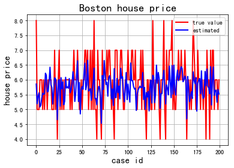

```python
if __name__ == "__main__":
    # -------------- 提取、分割数据 -------------
    train_data = pd.read_csv("./wine/train.csv")
    test_data = pd.read_csv("./wine/test.csv")

    train_X, train_Y = feature_label_split(train_data)
    test_X, test_Y = feature_label_split(test_data)

    unif_train_X, max_X, min_X = uniform_norm(train_X)
    unif_test_X = (test_X - min_X )/( max_X - min_X)

    unif_train_X = unif_train_X.T   # X shape : (3414, 11)
    unif_test_X = unif_test_X.T
    train_Y = train_Y.T
    test_Y = test_Y.T

    # -------------- 创建训练模块，执行训练 -------------

    model = linear_regression()
    model.fit(unif_train_X,train_Y,learning_rate=0.0001)

    # -------------- 查看训练结果 -------------

    print("训练集上效果评估 >>")
    pred_train = model.predict(unif_train_X)
    # print("R^2系数 ", model.score(unif_train_X, train_Y))
    print("均方误差 ",mean_squared_error(train_Y, pred_train))

    print("\n测试集上效果评估 >>")
    # r2 = model.score(unif_test_X, test_Y)
    # print("R^2系数 ",r2)
    pred = model.predict(unif_test_X)
    print("均方误差 ",mean_squared_error(test_Y, pred))
    # 等价于 print sum((pred - test_Y) ** 2)/test_Y.shape[0]

    # 下面对测试集上的标注值与预测值进行可视化呈现

    t = np.arange(len(pred.T[:200]))
    mpl.rcParams['font.sans-serif'] = [u'simHei']
    mpl.rcParams['axes.unicode_minus'] = False
    plt.figure(facecolor='w')
    plt.plot(t, test_Y.T[:200], 'r-', lw=2, label=u'true value')
    plt.plot(t, pred.T[:200], 'b-', lw=2, label=u'estimated')
    plt.legend(loc = 'best')
    plt.title(u'Boston house price', fontsize=18)
    plt.xlabel(u'case id', fontsize=15)
    plt.ylabel(u'house price', fontsize=15)
    plt.grid()
    plt.show()
```

显示了预测结果的前200个，总体上看，因为是简单是线性回归，从总的趋势上看，大概能够评估红酒质量是否高于平均水平。

但是由于数据集本身的特性，质量很高的红酒和质量很低的红酒，占比都很少，所以简单模型只能判断红酒质量相较于平均水平是偏上，还是偏下，对于选取高质量红酒，这么简单的模型也显得有些无能为力。